# Amazon Fine Food Reviews Analysis

### [5.1.2] Wordclouds of clusters obtained after applying k-means on BOW SET 1

```python
#choosing cluster size as 13, deciphered from above graph
bigrams_clusterer = KMeans(n_clusters=13, random_state=10, n_jobs=-1)
bigrams_clusterer.fit(bigrams)
```

```
KMeans(algorithm='auto', copy_x=True, init='k-means++', max_iter=300,
    n_clusters=13, n_init=10, n_jobs=-1, precompute_distances='auto',
    random_state=10, tol=0.0001, verbose=0)
```

```python
print("number of reviews in each cluster")
bigram_df = pd.DataFrame(data={"text":preprocessed_reviews,"labels":bigrams_clusterer.labels_})
bigram_df['labels'].value_counts()
```

```
number of reviews in each cluster
```

```
7     363912
5         84
6         60
4         41
3         41
11        23
12         2
9          2
1          2
10         1
8          1
2          1
0          1
Name: labels, dtype: int64
```

displaying only 6 clusters with random 20 review words

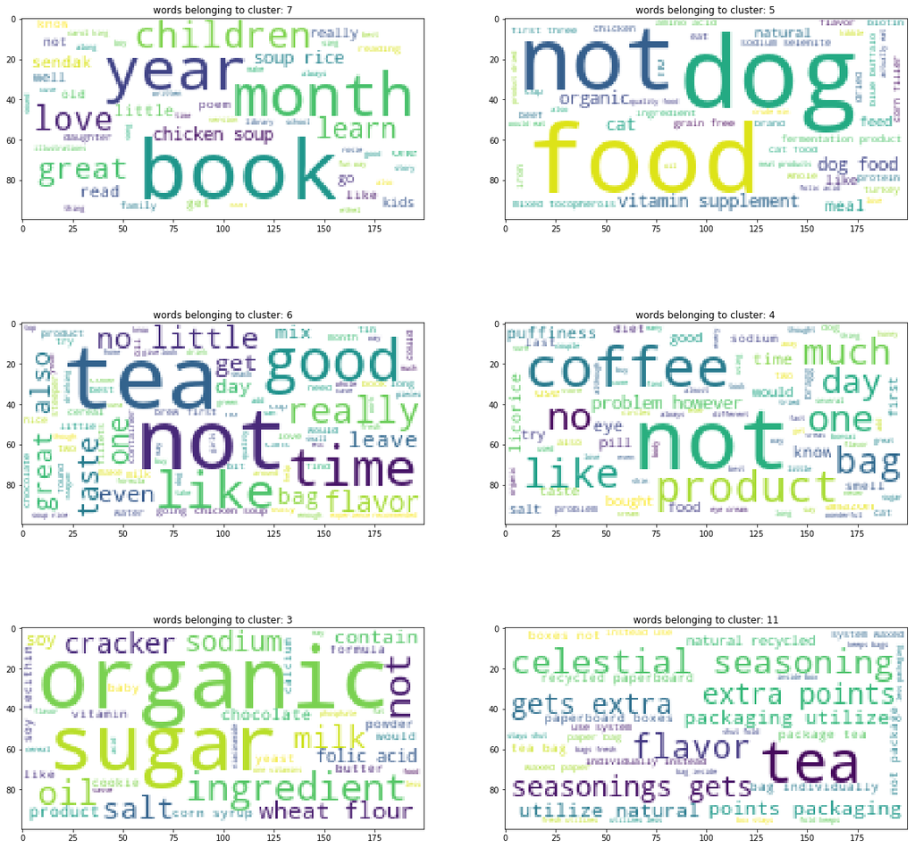

```python
import wordcloud
import random
from IPython.display import Markdown, display
display(Markdown("# &emsp;&emsp;&emsp;&emsp;&emsp;&emsp;displaying only 6 clusters with random 20 review words"))
fig, axs = plt.subplots(3,2, figsize=(20,20))
cluster_list = [7,5,6,4,3,11]
for ax,eachCluster in zip(axs.ravel(),cluster_list): #https://stackoverflow.com/a/17211410/12901493
    wordList = []
    #https://docs.python.org/3/library/random.html#random.sample
    for eachReview in random.sample(bigram_df[bigram_df.labels == eachCluster].text[:20].to_list(),20):
        for eachWord in eachReview.split(' '):
            wordList.append(eachWord)
    wordClud = wordcloud.WordCloud(width = 200, height = 100,
                                background_color ='white',
                                stopwords = stopwords).generate(' '.join(wordList))
    ax.imshow(wordClud)
    ax.set_title("words belonging to cluster: {:d}".format(eachCluster))

plt.show()
```

### [5.1.3] Applying K-Means Clustering on TFIDF, SET 2

```
inertia for cluster size 3 is :36164813148.31 and time taken:20.34mins
inertia for cluster size 5 is :36162848471.42 and time taken:35.99mins
inertia for cluster size 7 is :36162871404.09 and time taken:27.96mins
inertia for cluster size 11 is :36158944493.58 and time taken:34.01mins
inertia for cluster size 13 is :36155005157.84 and time taken:45.92mins
inertia for cluster size 17 is :36152618832.49 and time taken:48.52mins
```

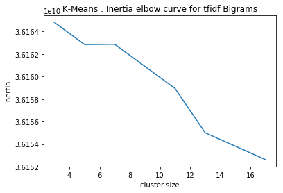

```python
range_n_clusters = [3, 5, 7, 11, 13, 17]
tfidf_inertia = []
for n_clusters in range_n_clusters:
    tfidf_clusterer = KMeans(n_clusters=n_clusters, random_state=10, n_jobs=-1)
    start = time.time()
    tfidf_clusterer.fit(tfidf_bigrams)
    timeTaken = time.time() - start
    tfidf_inertia.append(np.round(tfidf_clusterer.inertia_,2))
    print("inertia for cluster size {:d} is :{:0.2f} and time taken:{:0.2f}mins".
          format(n_clusters,tfidf_clusterer.inertia_,(timeTaken/60)))
plt.plot(range_n_clusters, tfidf_inertia)
plt.xlabel("cluster size")
plt.ylabel("inertia")
plt.title("K-Means : Inertia elbow curve for tfidf Bigrams")
```

### [5.1.4] Wordclouds of clusters obtained after applying k-means on TFIDF SET 2

```python
#choosing cluster size as 5, deciphered from above graph
tfidf_clusterer = KMeans(n_clusters=5, random_state=10, n_jobs=-1)
tfidf_clusterer.fit(tfidf_bigrams)
```

```
KMeans(algorithm='auto', copy_x=True, init='k-means++', max_iter=300,
    n_clusters=5, n_init=10, n_jobs=-1, precompute_distances='auto',
    random_state=10, tol=0.0001, verbose=0)
```

```python
print("number of reviews in each cluster")
tfidf_df = pd.DataFrame(data={"text":preprocessed_reviews,"labels":tfidf_clusterer.labels_})
tfidf_df['labels'].value_counts()
```

```
number of reviews in each cluster
```

```
2    364083
4        63
1        23
3         1
0         1
Name: labels, dtype: int64
```

displaying only 3 clusters with random 20 review words

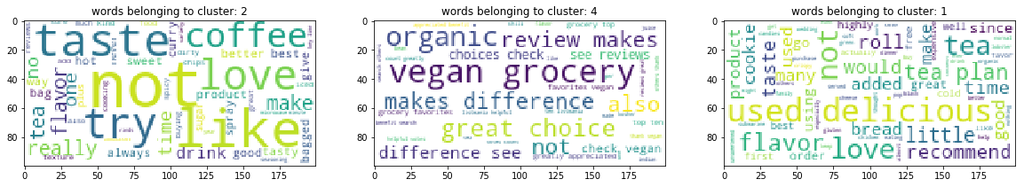

```python
display(Markdown("# &emsp;&emsp;&emsp;&emsp;&emsp;&emsp;displaying only 3 clusters with random 20 review words"))
fig, axs = plt.subplots(1,3, figsize=(20,10))
cluster_list = [2,4,1]
for ax,eachCluster in zip(axs.ravel(),cluster_list):#https://stackoverflow.com/a/17211410/12901493
    wordList = []
    #https://docs.python.org/3/library/random.html#random.sample
    for eachReview in random.sample(tfidf_df[tfidf_df.labels == eachCluster].text.to_list(),20):
        for eachWord in eachReview.split(' '):
            wordList.append(eachWord)
    wordClud = wordcloud.WordCloud(width = 200, height = 100,
                                background_color ='white',
                                stopwords = stopwords).generate(' '.join(wordList))
    ax.imshow(wordClud)
    ax.set_title("words belonging to cluster: {:d}".format(eachCluster))

plt.show()
```

### [5.1.5] Applying K-Means Clustering on AVG W2V, SET 3

```
inertia for cluster size 3 is :35160724.50 and time taken:0.57mins
inertia for cluster size 5 is :34474762.23 and time taken:1.94mins
inertia for cluster size 7 is :33939578.80 and time taken:0.93mins
inertia for cluster size 11 is :33261689.09 and time taken:1.27mins
inertia for cluster size 13 is :33044577.74 and time taken:2.31mins
inertia for cluster size 17 is :32688094.69 and time taken:2.71mins
inertia for cluster size 23 is :32276209.05 and time taken:3.73mins
inertia for cluster size 29 is :31996361.79 and time taken:4.21mins
```

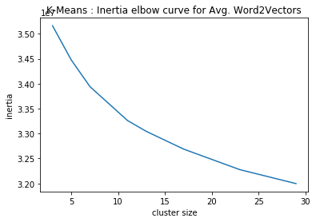

```python
range_n_clusters = [3, 5, 7, 11, 13, 17, 23, 29]
avgw2v_inertia = []
for n_clusters in range_n_clusters:
    avgw2v_clusterer = KMeans(n_clusters=n_clusters, random_state=10, n_jobs=-1)
    start = time.time()
    avgw2v_clusterer.fit(Word2Vectors)
    timeTaken = time.time() - start
    avgw2v_inertia.append(np.round(avgw2v_clusterer.inertia_,2))
    print("inertia for cluster size {:d} is :{:0.2f} and time taken:{:0.2f}mins".
          format(n_clusters,avgw2v_clusterer.inertia_,(timeTaken/60)))
plt.plot(range_n_clusters,avgw2v_inertia)
plt.xlabel("cluster size")
plt.ylabel("inertia")
plt.title("K-Means : Inertia elbow curve for Avg. Word2Vectors")
```

### [5.1.6] Wordclouds of clusters obtained after applying k-means on AVG W2V SET 3

```python
#choosing cluster size as 7, deciphered from above graph
avgw2v_clusterer = KMeans(n_clusters=7, random_state=10, n_jobs=-1)
avgw2v_clusterer.fit(Word2Vectors)
```

```
KMeans(algorithm='auto', copy_x=True, init='k-means++', max_iter=300,
    n_clusters=7, n_init=10, n_jobs=-1, precompute_distances='auto',
    random_state=10, tol=0.0001, verbose=0)
```

```python
print("number of reviews in each cluster")
avgw2v_df = pd.DataFrame(data={"text":preprocessed_reviews,"labels":avgw2v_clusterer.labels_})
avgw2v_df['labels'].value_counts()
```

```
number of reviews in each cluster
```

```
4    138682
6     66367
0     58440
1     31445
3     28290
5     22167
2     18780
Name: labels, dtype: int64
```

displaying only 7 clusters with random 20 review words

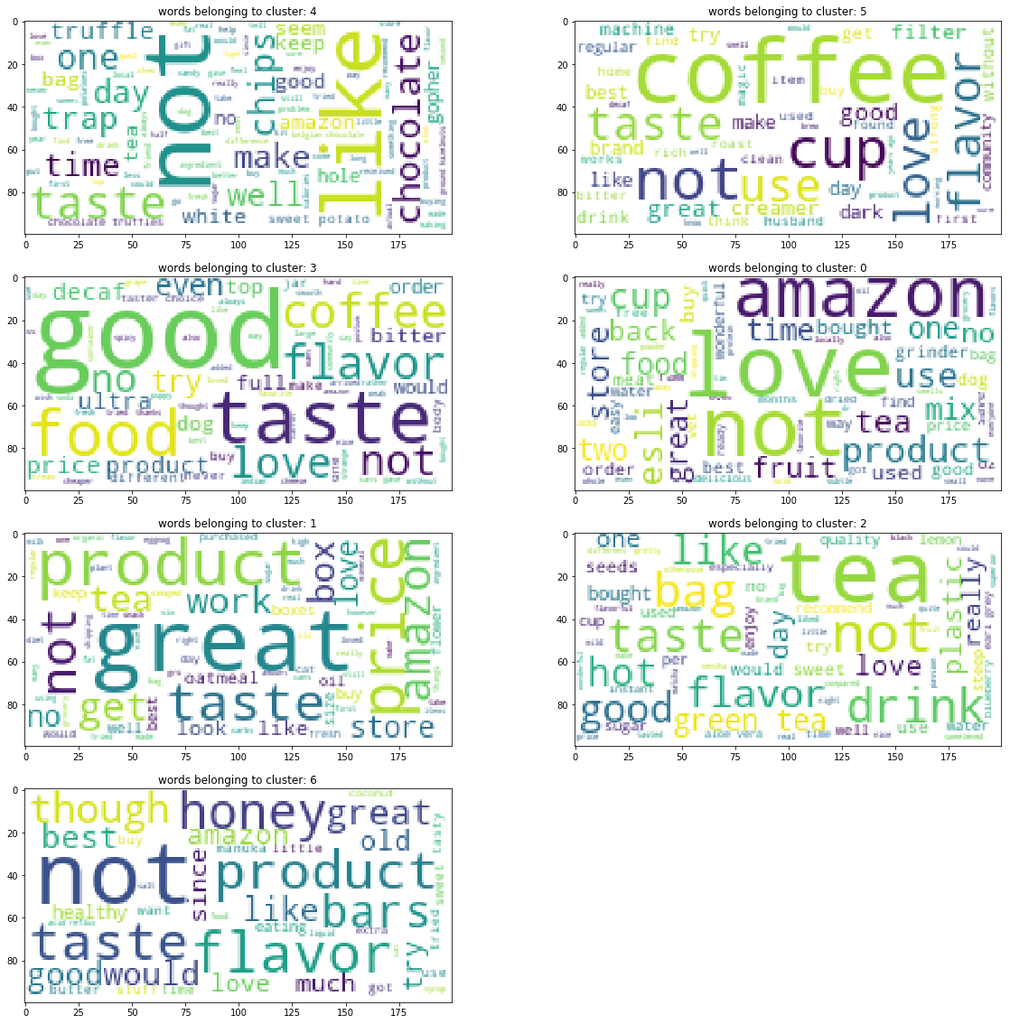

```python
display(Markdown("# &emsp;&emsp;&emsp;&emsp;&emsp;&emsp;displaying only 7 clusters with random 20 review words"))
fig, axs = plt.subplots(4,2, figsize=(20,20))
cluster_list = [4,5,3,0,1,2,6]
for ax,eachCluster in zip(axs.ravel(),cluster_list):#https://stackoverflow.com/a/17211410/12901493
    wordList = []
    #https://docs.python.org/3/library/random.html#random.sample
    for eachReview in random.sample(avgw2v_df[avgw2v_df.labels == eachCluster].text.to_list(),20):
        for eachWord in eachReview.split(' '):
            wordList.append(eachWord)
    wordClud = wordcloud.WordCloud(width = 200, height = 100,
                                background_color ='white',
                                stopwords = stopwords).generate(' '.join(wordList))
    ax.imshow(wordClud)
    ax.set_title("words belonging to cluster: {:d}".format(eachCluster))
axs[3,1].remove() #https://matplotlib.org/3.1.1/api/_as_gen/matplotlib.axes.Axes.remove.html
plt.draw()
```

### [5.1.7] Applying K-Means Clustering on TFIDF W2V, SET 4

```
inertia for cluster size 3 is :34780447.63 and time taken:0.46mins
inertia for cluster size 5 is :34010507.24 and time taken:0.95mins
inertia for cluster size 7 is :33560667.18 and time taken:1.40mins
inertia for cluster size 11 is :32913193.57 and time taken:2.64mins
inertia for cluster size 13 is :32657775.94 and time taken:2.27mins
inertia for cluster size 17 is :32186352.40 and time taken:2.89mins
inertia for cluster size 23 is :31594360.01 and time taken:3.36mins
inertia for cluster size 29 is :31063158.24 and time taken:4.49mins
```

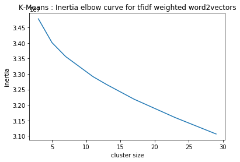

```python
range_n_clusters = [3, 5, 7, 11, 13, 17, 23, 29]
tfidfavgw2v_inertia = []
for n_clusters in range_n_clusters:
    tfidfavgw2v_clusterer = KMeans(n_clusters=n_clusters, random_state=10, n_jobs=-1)
    start = time.time()
    tfidfavgw2v_clusterer.fit(TfidfWord2Vectors)
    timeTaken = time.time() - start
    tfidfavgw2v_inertia.append(np.round(tfidfavgw2v_clusterer.inertia_,2))
    print("inertia for cluster size {:d} is :{:0.2f} and time taken:{:0.2f}mins".
          format(n_clusters,tfidfavgw2v_clusterer.inertia_,(timeTaken/60)))
plt.plot(range_n_clusters,tfidfavgw2v_inertia)
plt.xlabel("cluster size")
plt.ylabel("inertia")
plt.title("K-Means : Inertia elbow curve for tfidf weighted word2vectors")
```

### [5.1.8] Wordclouds of clusters obtained after applying k-means on TFIDF W2V SET 4

```python
#choosing cluster size as 5, deciphered from above graph
tfidfavgw2v_clusterer = KMeans(n_clusters=5, random_state=10, n_jobs=-1)
tfidfavgw2v_clusterer.fit(TfidfWord2Vectors)
```

```
KMeans(algorithm='auto', copy_x=True, init='k-means++', max_iter=300,
    n_clusters=5, n_init=10, n_jobs=-1, precompute_distances='auto',
    random_state=10, tol=0.0001, verbose=0)
```

```python
print("number of reviews in each cluster")
tfidfavgw2v_df = pd.DataFrame(data={"text":preprocessed_reviews,"labels":tfidfavgw2v_clusterer.labels_})
tfidfavgw2v_df['labels'].value_counts()
```

```
number of reviews in each cluster
```

```
4    149927
0    104530
2     84559
3     13378
1     11777
Name: labels, dtype: int64
```

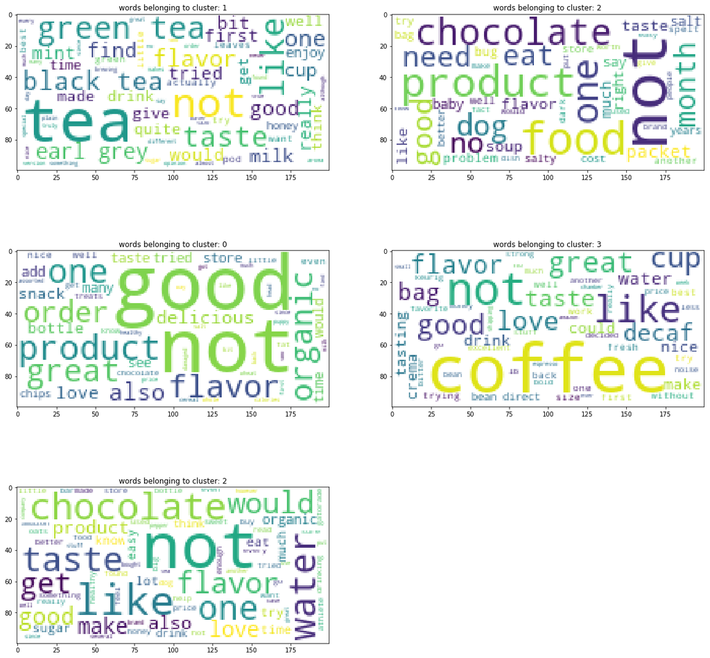

```python
display(Markdown("# &emsp;&emsp;&emsp;&emsp;&emsp;&emsp;displaying only 5 clusters with random 20 review words"))
fig, axs = plt.subplots(3,2, figsize=(20,20))
cluster_list = [1,2,0,3,2]
for ax,eachCluster in zip(axs.ravel(),cluster_list):#https://stackoverflow.com/a/17211410/12901493
    wordList = []
    #https://docs.python.org/3/library/random.html#random.sample
    for eachReview in random.sample(tfidfavgw2v_df[tfidfavgw2v_df.labels == eachCluster].text.to_list(),20):
        for eachWord in eachReview.split(' '):
            wordList.append(eachWord)
    wordClud = wordcloud.WordCloud(width = 200, height = 100,
                                background_color ='white',
                                stopwords = stopwords).generate(' '.join(wordList))
    ax.imshow(wordClud)
    ax.set_title("words belonging to cluster: {:d}".format(eachCluster))
axs[2,1].remove() #https://matplotlib.org/3.1.1/api/_as_gen/matplotlib.axes.Axes.remove.html
plt.draw()
```

## [5.2] Agglomerative Clustering

*Hierarchical clustering* is a general family of clustering algorithms that build nested clusters by merging or splitting them successively. This hierarchy of clusters is represented as a tree (or dendrogram). The root of the tree is the unique cluster that gathers all the samples, the leaves being the clusters with only one sample.

The *AgglomerativeClustering* object performs a hierarchical clustering using a bottom up approach: each observation starts in its own cluster, and clusters are successively merged together. The linkage criteria determines the metric used for the merge strategy:

- Ward minimizes the sum of squared differences within all clusters. It is a variance-minimizing approach and in this sense is similar to the k-means objective function but tackled with an agglomerative hierarchical approach.
- Maximum or complete linkage minimizes the maximum distance between observations of pairs of clusters.
- Average linkage minimizes the average of the distances between all observations of pairs of clusters.
- Single linkage minimizes the distance between the closest observations of pairs of clusters.

*AgglomerativeClustering* can also scale to large number of samples when it is used jointly with a connectivity matrix, but is computationally expensive when no connectivity constraints are added between samples: it considers at each step all the possible merges.

[figure not shown]

**Dendogram** the root of the tree is the unique cluster that gathers all the samples. The leaves being the clusters with only one sample. The decision of the no. of clusters that can best depict different groups can be chosen by obeserving the dendogram. The best chioce of the no. of clusters is the no. of vertical lines in the dendogram cut by a horizontal line that can transverse the maximum distance vertically without intersecting a cluster

[figure not shown]

source: Scikit-Learn & [Avik-Jain Github](https://github.com/Avik-Jain/100-Days-Of-ML-Code#hierarchical-clustering--day-54)

### [5.2.1] Applying Agglomerative Clustering on AVG W2V, SET 3

```python
from sklearn.cluster import AgglomerativeClustering
avgw2v_agglo = AgglomerativeClustering(n_clusters=5,
                                       affinity='euclidean',
                                       memory=None,
                                       connectivity=None,
                                       compute_full_tree='auto',
                                       linkage='ward')
start = time.time()
avgw2v_agglo.fit(Word2Vectors[:50000])
timeTaken = time.time() - start
print("time taken for fitting :{:0.2f} mins".format(timeTaken/60))
```

```
time taken for fitting :6.73 mins
```

```python
print("number of reviews in each cluster")
avgw2v_agglo_df = pd.DataFrame(data={"text":preprocessed_reviews[:50000],"labels":avgw2v_agglo.labels_})
avgw2v_agglo_df['labels'].value_counts()
```

```
number of reviews in each cluster
```

```
4    29381
2     7984
0     4540
1     4463
3     3632
Name: labels, dtype: int64
```

### [5.2.2] Wordclouds of clusters obtained after applying Agglomerative Clustering on AVG W2V SET 3

displaying only 5 clusters with random 20 review words

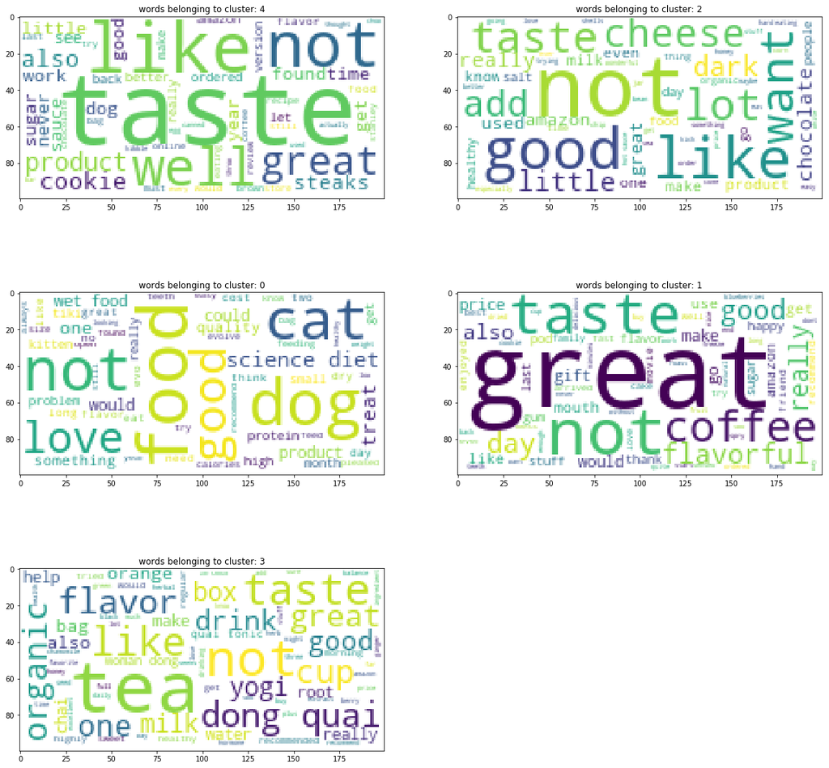

```python
display(Markdown("# &emsp;&emsp;&emsp;&emsp;&emsp;&emsp;displaying only 5 clusters with random 20 review words"))
fig, axs = plt.subplots(3,2, figsize=(20,20))
cluster_list = [4,2,0,1,3]
for ax,eachCluster in zip(axs.ravel(),cluster_list):#https://stackoverflow.com/a/17211410/12901493
    wordList = []
    #https://docs.python.org/3/library/random.html#random.sample
    for eachReview in random.sample(avgw2v_agglo_df[avgw2v_agglo_df.labels == eachCluster].text.to_list(),20):
        for eachWord in eachReview.split(' '):
            wordList.append(eachWord)
    wordClud = wordcloud.WordCloud(width = 200, height = 100,
                                background_color ='white',
                                stopwords = stopwords).generate(' '.join(wordList))
    ax.imshow(wordClud)
    ax.set_title("words belonging to cluster: {:d}".format(eachCluster))
axs[2,1].remove() #https://matplotlib.org/3.1.1/api/_as_gen/matplotlib.axes.Axes.remove.html
plt.draw()
```

### [5.2.3] Applying Agglomerative Clustering on TFIDF W2V, SET 4

```python
from sklearn.cluster import AgglomerativeClustering
tfidfw2v_agglo = AgglomerativeClustering(n_clusters=5,
                                       affinity='euclidean',
                                       memory=None,
                                       connectivity=None,
                                       compute_full_tree='auto',
                                       linkage='ward')
start = time.time()
tfidfw2v_agglo.fit(TfidfWord2Vectors[100000:150000])
timeTaken = time.time() - start
print("time taken for fitting :{:0.2f} mins".format(timeTaken/60))
```

```
time taken for fitting :6.61 mins
```

```python
print("number of reviews in each cluster")
tfidfw2v_agglo_df = pd.DataFrame(data={"text":preprocessed_reviews[100000:150000],"labels":tfidfw2v_agglo.labels_})
tfidfw2v_agglo_df['labels'].value_counts()
```

```
number of reviews in each cluster
```

```
1    43775
0     3394
4     1551
2      927
3      353
Name: labels, dtype: int64
```

### [5.2.4] Wordclouds of clusters obtained after applying Agglomerative Clustering on TFIDF W2V SET 4

displaying only 5 clusters with random 20 review words

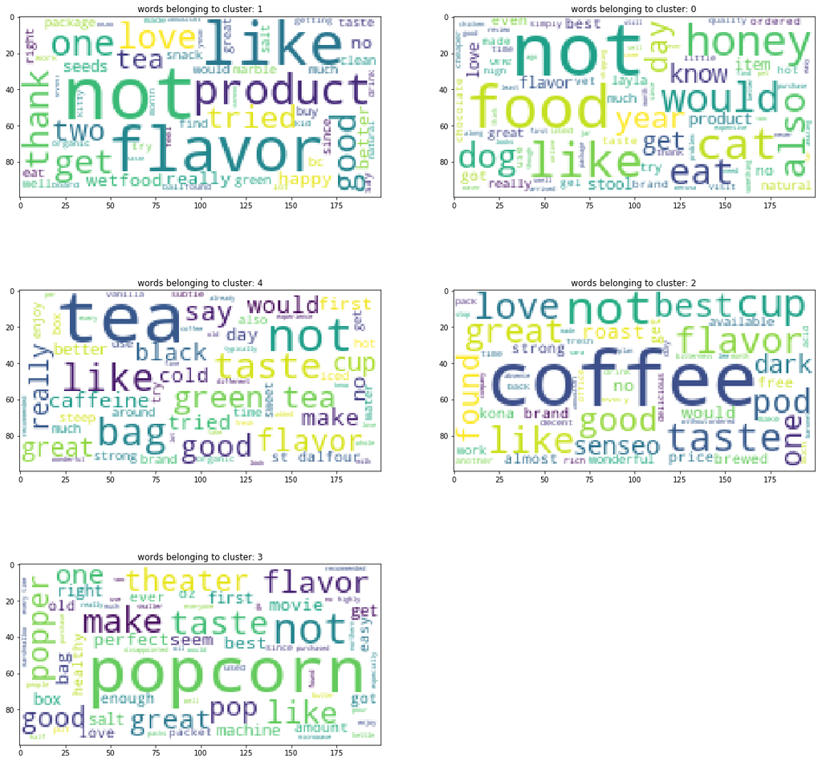

```python
display(Markdown("# &emsp;&emsp;&emsp;&emsp;&emsp;&emsp;displaying only 5 clusters with random 20 review words"))
fig, axs = plt.subplots(3,2, figsize=(20,20))
cluster_list = [1,0,4,2,3]
for ax,eachCluster in zip(axs.ravel(),cluster_list):#https://stackoverflow.com/a/17211410/12901493
    wordList = []
    #https://docs.python.org/3/library/random.html#random.sample
    for eachReview in random.sample(tfidfw2v_agglo_df[tfidfw2v_agglo_df.labels == eachCluster].text.to_list(),20):
        for eachWord in eachReview.split(' '):
            wordList.append(eachWord)
    wordClud = wordcloud.WordCloud(width = 200, height = 100,
                                background_color ='white',
                                stopwords = stopwords).generate(' '.join(wordList))
    ax.imshow(wordClud)
    ax.set_title("words belonging to cluster: {:d}".format(eachCluster))
axs[2,1].remove() #https://matplotlib.org/3.1.1/api/_as_gen/matplotlib.axes.Axes.remove.html
plt.draw()
```

## [5.3] DBSCAN Clustering

The **DBSCAN** algorithm views clusters as areas of high density separated by areas of low density. Due to this rather generic view, clusters found by DBSCAN can be any shape, as opposed to k-means which assumes that clusters are convex shaped. The central component to the DBSCAN is the concept of *core samples*, which are samples that are in areas of high density. A cluster is therefore a set of core samples, each close to each other (measured by some distance measure) and a set of non-core samples that are close to a core sample (but are not themselves core samples). There are two parameters to the algorithm, *min_samples* and $\mathbf{ \varepsilon}$, which define formally what we mean when we say dense. Higher *min_samples* or lower $\mathbf{ \varepsilon}$ indicate higher density necessary to form a cluster.

Consider a set of points in some space to be clustered. Let ε be a parameter specifying the radius of a neighborhood with respect to some point. For the purpose of DBSCAN clustering, the points are classified as *core points, (density-)reachable points* and *outliers*, as follows:

- A point $p$ is a core point if at least **minPts** points are within distance $\mathbf{ \varepsilon}$ of it (including $p$).
- A point $q$ is directly reachable from $p$ if point $q$ is within distance $\mathbf{ \varepsilon}$ from core point $p$. Points are only said to be directly reachable from core points.
- A point $q$ is reachable from $p$ if there is a path $p_1, ..., p_n$ with $p_1 = p$ and $p_n = q$, where each $p_{i+1}$ is directly reachable from $p_i$. Note that this implies that all points on the path must be core points, with the possible exception of $q$.
- All points not reachable from any other point are outliers or noise points.

Now if $p$ is a core point, then it forms a *cluster* together with all points (core or non-core) that are reachable from it. Each cluster contains at least one core point; non-core points can be part of a cluster, but they form its "edge", since they cannot be used to reach more points.

[figure not shown]

**Reachability** is not a symmetric relation since, by definition, no point may be reachable from a non-core point, regardless of distance (so a non-core point may be reachable, but nothing can be reached from it). Therefore, a further notion of connectedness is needed to formally define the extent of the clusters found by DBSCAN. Two points p and q are density-connected if there is a point o such that both p and q are reachable from o. Density-connectedness is symmetric.

A cluster then satisfies two properties:

1. All points within the cluster are mutually density-connected.
2. If a point is density-reachable from some point of the cluster, it is part of the cluster as well.

##### Abstract Algorithm

The DBSCAN algorithm can be abstracted into the following steps:

1. Find the points in the $\mathbf{ \varepsilon}$ neighborhood of every point, and identify the core points with more than **minPts** neighbors.
2. Find the connected components of core points on the neighbor graph, ignoring all non-core points.
3. Assign each non-core point to a nearby cluster if the cluster is an $\mathbf{ \varepsilon}$ neighbor, otherwise assign it to noise.

A naive implementation of this requires storing the neighborhoods in step 1, thus requiring substantial memory. The original DBSCAN algorithm does not require this by performing these steps for one point at a time.

Source: Wikipedia

### [5.3.1] Applying DBSCAN on AVG W2V, SET 3

```python
from sklearn.cluster import DBSCAN
print("-1 cluster label is outliers")
for eachEpsilon in [0.5,1,2]:
    avgw2v_DBSCAN = DBSCAN(eps=eachEpsilon,
                      min_samples=5,
                      metric='euclidean',
                      metric_params=None,
                      algorithm='auto',
                      leaf_size=30,
                      p=None,
                      n_jobs=-1)
    start = time.time()
    avgw2v_DBSCAN.fit(Word2Vectors[:50000])
    timeTaken = time.time() - start
    print("epsilon - {:.2f}, core samples - {:d}, time taken - {:.2f}mins".
          format(eachEpsilon,len(avgw2v_DBSCAN.core_sample_indices_),(timeTaken/60)))
    print("number of reviews in each cluster")
    avgw2v_DBSCAN_df = pd.DataFrame(data={"text":preprocessed_reviews[:50000],"labels":avgw2v_DBSCAN.labels_})
    print(avgw2v_DBSCAN_df['labels'].value_counts())
```

```
-1 cluster label is outliers
epsilon - 0.50, core samples - 146, time taken - 0.22mins
number of reviews in each cluster
-1    49854
 0      141
 1        5
Name: labels, dtype: int64
epsilon - 1.00, core samples - 151, time taken - 0.97mins
number of reviews in each cluster
-1    49849
 0      141
 2        5
 1        5
Name: labels, dtype: int64
epsilon - 2.00, core samples - 160, time taken - 3.59mins
number of reviews in each cluster
-1    49837
 1      141
 3        6
 2        6
 4        5
 0        5
Name: labels, dtype: int64
```

### [5.3.2] Wordclouds of clusters obtained after applying DBSCAN on AVG W2V SET 3

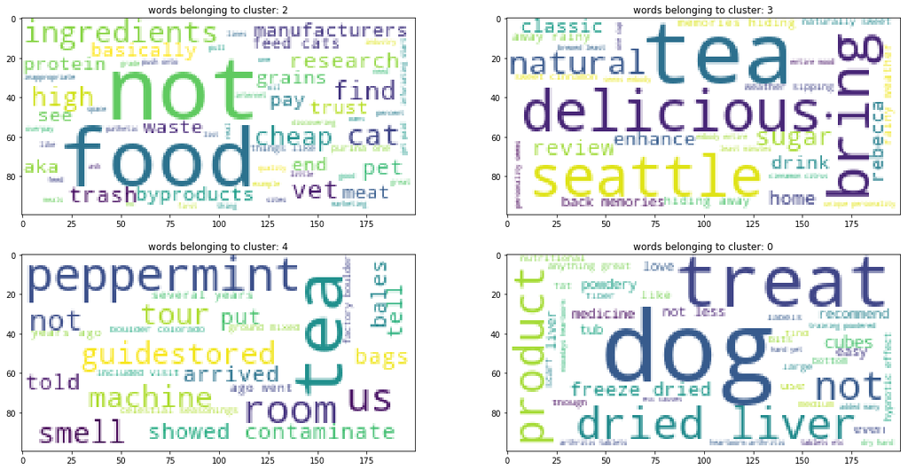

```python
display(Markdown("# &emsp;&emsp;&emsp;&emsp;&emsp;&emsp;displaying only 4 clusters with random 4 review's words"))
fig, axs = plt.subplots(2,2, figsize=(20,10))
cluster_list = [2,3,4,0]
for ax,eachCluster in zip(axs.ravel(),cluster_list):#https://stackoverflow.com/a/17211410/12901493
    wordList = []
    #https://docs.python.org/3/library/random.html#random.sample
    for eachReview in random.sample(avgw2v_DBSCAN_df[avgw2v_DBSCAN_df.labels == eachCluster].text.to_list(),3):
        for eachWord in eachReview.split(' '):
            wordList.append(eachWord)
    wordClud = wordcloud.WordCloud(width = 200, height = 100,
                                background_color ='white',
                                stopwords = stopwords).generate(' '.join(wordList))
    ax.imshow(wordClud)
    ax.set_title("words belonging to cluster: {:d}".format(eachCluster))
plt.draw()
```

### [5.3.3] Applying DBSCAN on TFIDF W2V, SET 4

```python
print("-1 cluster label is outliers")
for eachEpsilon in [0.5,1,2]:
    tfidfw2v_DBSCAN = DBSCAN(eps=eachEpsilon,
                      min_samples=5,
                      metric='euclidean',
                      metric_params=None,
                      algorithm='auto',
                      leaf_size=30,
                      p=None,
                      n_jobs=-1)
    start = time.time()
    tfidfw2v_DBSCAN.fit(TfidfWord2Vectors[100000:150000])
    timeTaken = time.time() - start
    print("epsilon - {:.2f}, core samples - {:d}, time taken - {:.2f}mins".
          format(eachEpsilon,len(avgw2v_DBSCAN.core_sample_indices_),(timeTaken/60)))
    print("number of reviews in each cluster")
    tfidfw2v_DBSCAN_df = pd.DataFrame(data={"text":preprocessed_reviews[:50000],"labels":tfidfw2v_DBSCAN.labels_})
    print(tfidfw2v_DBSCAN_df['labels'].value_counts())
```

```
-1 cluster label is outliers
epsilon - 0.50, core samples - 160, time taken - 0.26mins
number of reviews in each cluster
-1    49822
 0      170
 1        8
Name: labels, dtype: int64
epsilon - 1.00, core samples - 160, time taken - 1.03mins
number of reviews in each cluster
-1    49821
 0      170
 1        9
Name: labels, dtype: int64
epsilon - 2.00, core samples - 160, time taken - 4.51mins
number of reviews in each cluster
-1    49821
 0      170
 1        9
Name: labels, dtype: int64
```

### [5.3.4] Wordclouds of clusters obtained after applying DBSCAN on TFIDF W2V SET 4

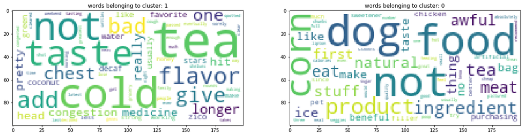

```python
display(Markdown("# &emsp;&emsp;&emsp;&emsp;&emsp;&emsp;displaying only 2 clusters with random 4 review's words"))
fig, axs = plt.subplots(1,2, figsize=(20,10))
cluster_list = [1,0]
for ax,eachCluster in zip(axs.ravel(),cluster_list):#https://stackoverflow.com/a/17211410/12901493
    wordList = []
    #https://docs.python.org/3/library/random.html#random.sample
    for eachReview in random.sample(tfidfw2v_DBSCAN_df[tfidfw2v_DBSCAN_df.labels == eachCluster].text.to_list(),5):
        for eachWord in eachReview.split(' '):
            wordList.append(eachWord)
    wordClud = wordcloud.WordCloud(width = 200, height = 100,
                                background_color ='white',
                                stopwords = stopwords).generate(' '.join(wordList))
    ax.imshow(wordClud)
    ax.set_title("words belonging to cluster: {:d}".format(eachCluster))
plt.draw()
```

# [6] Conclusions

```python
from prettytable import PrettyTable

table = PrettyTable()
table.field_names = ["K-Means++", "No. of Clusters", "Inertia"]
table.add_row(["bigrams(BOW)", bigrams_clusterer.n_clusters, bigrams_clusterer.inertia_])
table.add_row(["bigrams(tfidf)",tfidf_clusterer.n_clusters,tfidf_clusterer.inertia_])
table.add_row(["Avg. Word2Vec",avgw2v_clusterer.n_clusters,avgw2v_clusterer.inertia_])
table.add_row(["tfidf Word2Vec",tfidfavgw2v_clusterer.n_clusters,tfidfavgw2v_clusterer.inertia_])
```

```python
print(table)
```

```
+----------------+-----------------+--------------------+
|   K-Means++    | No. of Clusters |      Inertia       |
+----------------+-----------------+--------------------+
|  bigrams(BOW)  |        13       | 36137781197.304436 |
| bigrams(tfidf) |        5        | 36162848471.42067  |
| Avg. Word2Vec  |        7        | 33939578.799190745 |
| tfidf Word2Vec |        5        | 34010507.23937587  |
+----------------+-----------------+--------------------+
```